# “Praktikum 04 - Pembangkitan Arma”

Angga Fathan Rofiqy

21 September, 2023

# 1 Rpubs

https://rpubs.com/ZenR_Prog/MPDW-Prak04

## 1.1 White Noise

Pembangkitan data berpola AR, MA, ARMA, dan banyak proses deret waktu lainnya diawali pembangkitan *white noise*. *White noise* merupakan sederet nilai dari peubah bebas stokastik identik. Oleh karena itu, *white noise* memiliki dua karakteristik penting:

1. *White noise* tidak memiliki autokorelasi (**karena saling bebas**)
2. Nilai harapan dan ragam *white noise* sama (**karena berasal dari peubah acak bebas stokastik identik**)

*White noise* dibangkitkan dari suatu peubah acak, umumnya peubah acak normal.

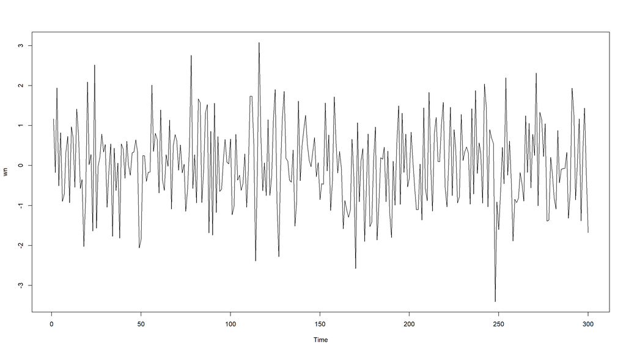

```r
wn <- rnorm(300)
ts.plot(wn)
```

Dapat terlihat bahwa *white noise* tidak memiliki autokorelasi dari ACF. Perhatikan bahwa lag ke-0 adalah korelasi observasi ke-t dengan dirinya sendiri. Nilai korelasi tersebut pasti 1. Sebagai alternatif, lag pertama di plot ACF dapat ditetapkan sebagai 1 (alih-alih 0) dengan menambahkan argumen `xlim(1, lag akhir)`. Plot tersebut dapat disandingkan bersamaan dengan membuat matriks $1 \times 2$ dengan `par(mfrow = c(1,2))`.

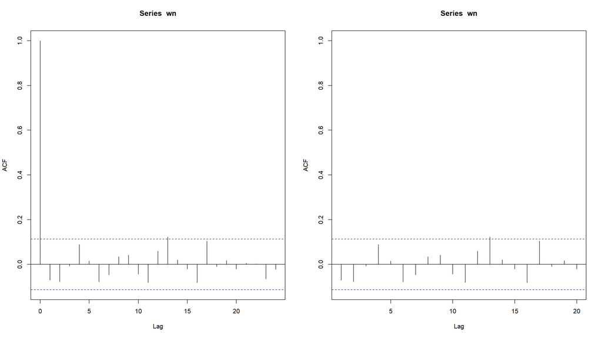

```r
par(mfrow = c(1, 2))
acf(wn)
acf(wn, xlim = c(1, 20))
```

# 2 Proses MA

Proses MA dapat dituliskan sebagai berikut:

$$y_{t} = c + e_t + \theta_{1}e_{t-1} + \theta_{2}e_{t-2} + \dots +
\theta_{q}e_{t-q} = c+{e_t+\sum_{i=1}^p \theta_ie_{t-i}}$$
Terlihat bahwa $e_t$, atau *white noise*, berperan penting dalam pembangkitan proses MA.

## 2.1 Pembangkitan Proses MA(2)

```r
set.seed(006)
ma <- wn[c(1,2)]
```

$$y_t = e_t + 0.4e_{t-1} + 0.6e_{t-2}$$

```r
for(i in 3:300){
   ma[i] <- wn[i] + 0.4 * wn[i - 1] + 0.6 * wn[i - 2]
}

install_load('DT')
datatable(as.matrix(ma), filter = 'top',
          options = list(pageLength = 5))
```

| V1 |
| --- |
| 1.169461112962039 |
| -0.176508114062097 |
| 2.574554590137149 |
| 0.163744273891437 |
| 1.786754500436379 |
| -0.8714719455304433 |
| -0.5785239916175438 |
| -0.4842837960346351 |
| 0.4399910827820994 |
| -0.4337946539307143 |

[output cut: 290 more lines]

Selain menggunakan cara di atas, pembangkitan proses MA(2) dapat dilakukan dengan fungsi `arima.sim()` sebagai berikut.

```r
ma2 <- arima.sim(list(order=c(0,0,2), ma=c(0.4, 0.6)), n=300)

datatable(as.matrix(ma2), filter = 'top',
          options = list(pageLength = 5))
```

| V1 |
| --- |
| 0.7784292512590714 |
| 1.696668199752581 |
| 1.236261745205178 |
| 1.414017543968744 |
| -1.14748164235089 |
| 0.4357553176235013 |
| -0.4452008192655633 |
| -0.5872748467443629 |
| 1.335416002822251 |
| -1.116497622916905 |

[output cut: 290 more lines]

### 2.2.1 Plot Time Series

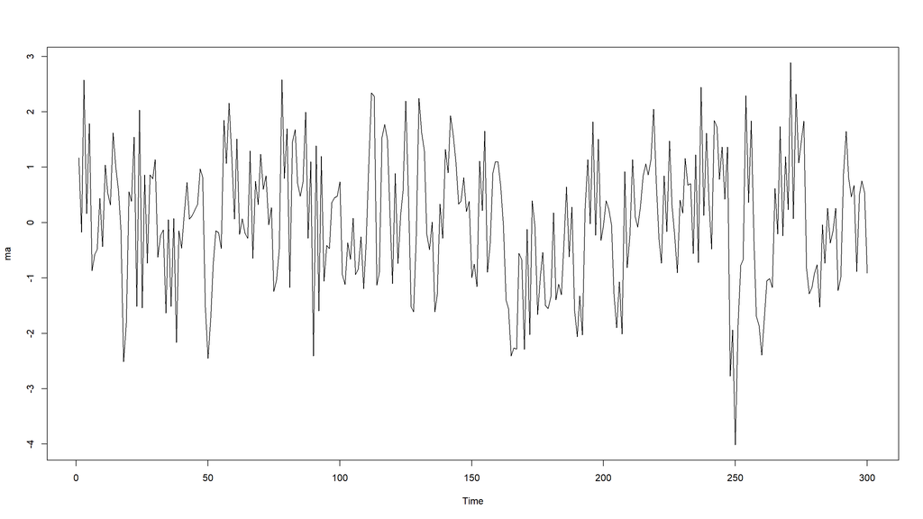

```r
ts.plot(ma)
```

Berdasarkan plot time series, terlihat bahwa data MA(2) yang dibangkitkan stasioner dalam rataan.

### 2.2.2 Plot ACF

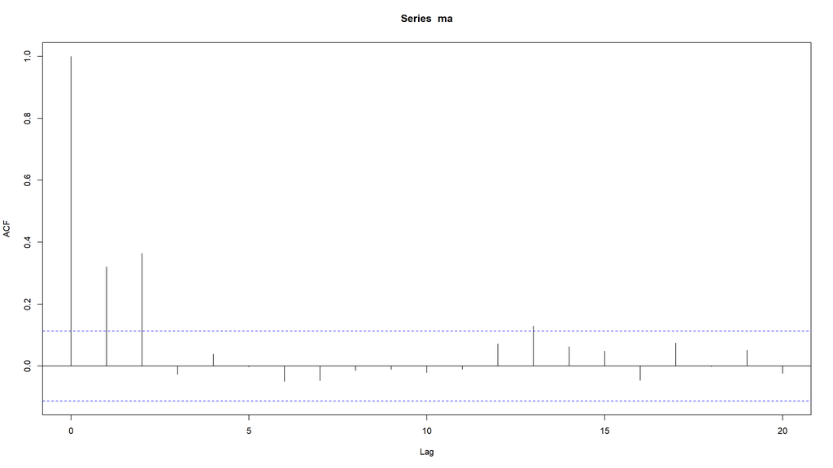

```r
acf(ma,lag.max = 20)
```

Berdasarkan plot AFC tersebut, terlihat bahwa plot ACF *cuts off* di lag kedua

### 2.2.3 Plot PACF

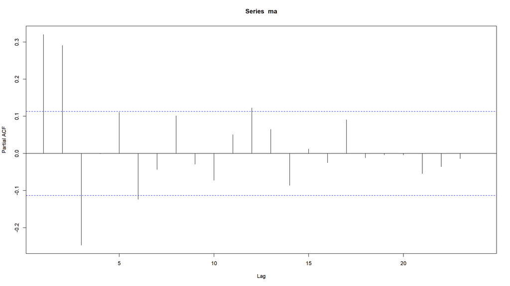

```r
pacf(ma)
```

Berdasarkan plot PACF tersebut, terlihat bahwa plot PACF cenderung *tails off* dan membentuk gelombang sinus

### 2.2.4 Plot EACF

```r
TSA::eacf(ma)
```

```
## AR/MA
##   0 1 2 3 4 5 6 7 8 9 10 11 12 13
## 0 x x o o o o o o o o o  o  x  o
## 1 x x x o o o o o o o o  o  o  o
## 2 x x o o o o o o o o o  o  x  o
## 3 o x o x o o o o o o o  o  o  o
## 4 o x x x o o o o o o o  o  o  o
## 5 x x x o o o o o o o o  o  o  o
## 6 x x x x o o o o o o o  o  o  o
## 7 x x x x o o o o o o o  o  o  o
```

Berdasarkan pola segitiga nol pada plot EACF, terlihat bahwa segitiga nol berada pada ordo AR(0) dan ordo MA(2)

Dari keempat plot tersebut, terlihat bahwa data stasioner.

## 2.3 Scatterplot Antar Lag

### 2.3.1 Korelasi antara $Y_t$ dengan $Y_{t-1}$

```r
#Yt
yt_ma <- ma[-1]
datatable(as.matrix(yt_ma), filter = 'top',
          options = list(pageLength = 5))
```

| V1 |
| --- |
| -0.176508114062097 |
| 2.574554590137149 |
| 0.163744273891437 |
| 1.786754500436379 |
| -0.8714719455304433 |
| -0.5785239916175438 |
| -0.4842837960346351 |
| 0.4399910827820994 |
| -0.4337946539307143 |
| 1.03837297056217 |

[output cut: 289 more lines]

```r
#Yt-1
yt_1_ma <- ma[-300]

datatable(as.matrix(yt_1_ma), filter = 'top',
          options = list(pageLength = 5))
```

| V1 |
| --- |
| 1.169461112962039 |
| -0.176508114062097 |
| 2.574554590137149 |
| 0.163744273891437 |
| 1.786754500436379 |
| -0.8714719455304433 |
| -0.5785239916175438 |
| -0.4842837960346351 |
| 0.4399910827820994 |
| -0.4337946539307143 |

[output cut: 289 more lines]

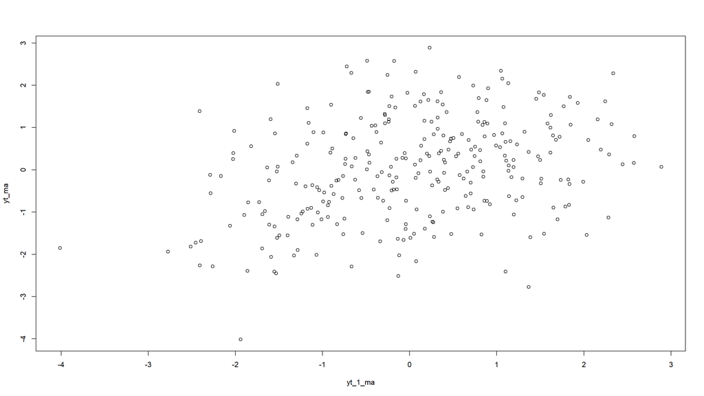

```r
plot(y=yt_ma,x=yt_1_ma)
```

Berdasarkan scatterplot tersebut, terlihat bahwa terdapat hubungan positif antara $Y_t$ dengan $Y_{t-1}$. Hal ini sesuai dengan teori yang ada

```r
cat("Nilai Korelasi : ", cor(yt_ma,yt_1_ma))
```

```
## Nilai Korelasi :  0.3213018
```

Korelasi antara $Y_t$ dengan $Y_{t-1}$ dari hasil simulasi mendekati perhitungan teoritis.

### 2.3.2 Korelasi antara $Y_t$ dengan $Y_{t-2}$

```r
#Yt
yt_ma2 <- ma[-c(1,2)]
datatable(as.matrix(yt_ma2), filter = 'top',
          options = list(pageLength = 5))
```

| V1 |
| --- |
| 2.574554590137149 |
| 0.163744273891437 |
| 1.786754500436379 |
| -0.8714719455304433 |
| -0.5785239916175438 |
| -0.4842837960346351 |
| 0.4399910827820994 |
| -0.4337946539307143 |
| 1.03837297056217 |
| 0.5329555143727563 |

[output cut: 288 more lines]

```r
#Yt-2
yt_2_ma <- ma[-c(299,300)]

datatable(as.matrix(yt_2_ma), filter = 'top',
          options = list(pageLength = 5))
```

| V1 |
| --- |
| 1.169461112962039 |
| -0.176508114062097 |
| 2.574554590137149 |
| 0.163744273891437 |
| 1.786754500436379 |
| -0.8714719455304433 |
| -0.5785239916175438 |
| -0.4842837960346351 |
| 0.4399910827820994 |
| -0.4337946539307143 |

[output cut: 288 more lines]

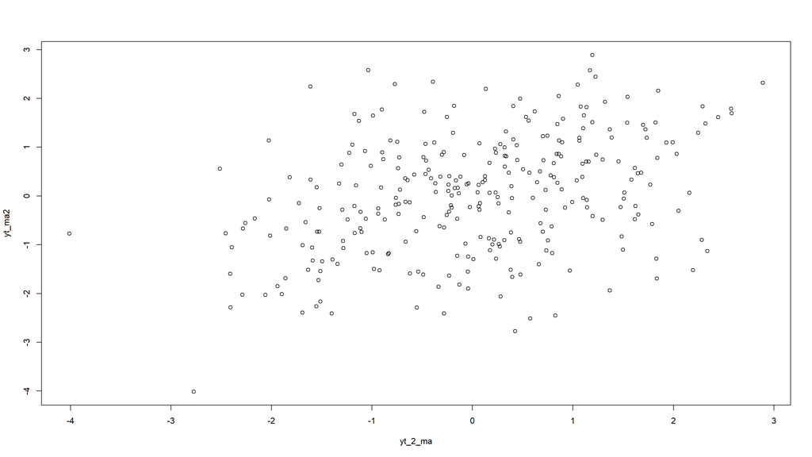

```r
plot(y=yt_ma2, x=yt_2_ma)
```

```r
cat("Nilai Korelasi : ", cor(yt_ma2,yt_2_ma))
```

```
## Nilai Korelasi :  0.364761
```

### 2.3.3 Korelasi antara $Y_t$ dengan $Y_{t-3}$

```r
#Yt
yt_ma3 <- ma[-c(1,2,3)]
datatable(as.matrix(yt_ma3), filter = 'top',
          options = list(pageLength = 5))
```

| V1 |
| --- |
| 0.163744273891437 |
| 1.786754500436379 |
| -0.8714719455304433 |
| -0.5785239916175438 |
| -0.4842837960346351 |
| 0.4399910827820994 |
| -0.4337946539307143 |
| 1.03837297056217 |
| 0.5329555143727563 |
| 0.3210598128147812 |

[output cut: 287 more lines]

```r
#Yt-2
yt_3_ma <- ma[-c(298,299,300)]

datatable(as.matrix(yt_3_ma), filter = 'top',
          options = list(pageLength = 5))
```

| V1 |
| --- |
| 1.169461112962039 |
| -0.176508114062097 |
| 2.574554590137149 |
| 0.163744273891437 |
| 1.786754500436379 |
| -0.8714719455304433 |
| -0.5785239916175438 |
| -0.4842837960346351 |
| 0.4399910827820994 |
| -0.4337946539307143 |

[output cut: 287 more lines]

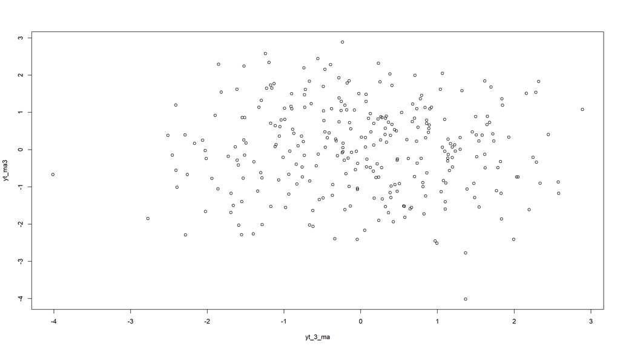

```r
plot(y=yt_ma3, x=yt_3_ma)
```

Berdasarkan scatterplot tersebut, terlihat bahwa cenderung tidak terdapat hubungan antara $Y_t$ dengan $Y_{t-3}$.

```r
cat("Nilai Korelasi : ", cor(yt_ma3, yt_3_ma))
```

```
## Nilai Korelasi :  -0.02723429
```

Korelasi antara $Y_t$ dengan $Y_{t-3}$ hasil simulasi mendekati teori yang ada yaitu $0$.

# 3 Proses AR

Proses AR dapat dituliskan sebagai berikut:

$$y_{t} = c + e_t + \phi_{1}Y_{t-1} +
\phi_{2}Y_{t-2} + \dots + \phi_{q}Y_{t-q} = c+{e_t+\sum_{i=1}^p
\phi_iY_{t-i}}$$
Terlihat bahwa $Y_t$ berperan penting dalam pembangkitan proses AR.

## 3.1 Pembangkitan Proses AR

```r
set.seed(006)
```

$$Y_t = e_t+ 0.5Y_{t-1} + 0.2Y_{t-2}$$

```r
n<-length(wn)
cat("n : ", n)
```

```
## n :  300
```

```r
ar <- c(1:n)
for (i in 3:n) {ar[i]<-wn[i]+0.5*ar[i-1]+0.2*ar[i-2]}
datatable(as.matrix(ar), filter = 'top',
          options = list(pageLength = 5))
```

| V1 |
| --- |
| 1 |
| 2 |
| 3.143481167984765 |
| 1.463997259127172 |
| 2.184457992752144 |
| 0.4886972457535475 |
| -0.03300916696612072 |
| 0.4204495464591185 |
| 0.9364777833378407 |
| -0.3781365988454542 |

[output cut: 290 more lines]

Selain menggunakan cara di atas, pembangkitan proses AR dapat dilakukan dengan fungsi `arima.sim()` sebagai berikut.

```r
ar2 <- arima.sim(list(order=c(2,0,0), ar=c(0.5,0.2)), n=300)
datatable(as.matrix(ar2), filter = 'top',
          options = list(pageLength = 5))
```

| V1 |
| --- |
| -0.9217356731617842 |
| -0.3880567759800302 |
| 1.975828738354549 |
| 2.30372927335444 |
| 0.9866980255699501 |
| 0.2826354838850864 |
| 0.8310959017874734 |
| -0.7073154685053005 |
| -1.246156005806758 |
| 0.373361516395682 |

[output cut: 290 more lines]

## 3.2 Karakteristik AR(2)

### 3.2.1 Plot Time Series

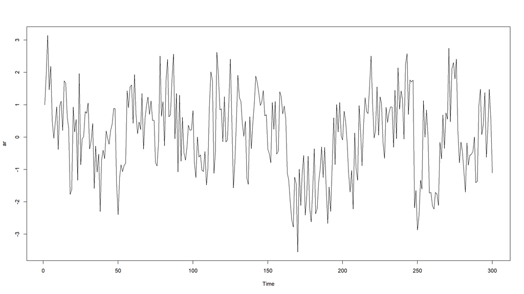

```r
ts.plot(ar)
```

Berdasarkan plot time series tersebut terlihat bahwa data cenderung stasioner pada rataan

### 3.2.2 Plot ACF

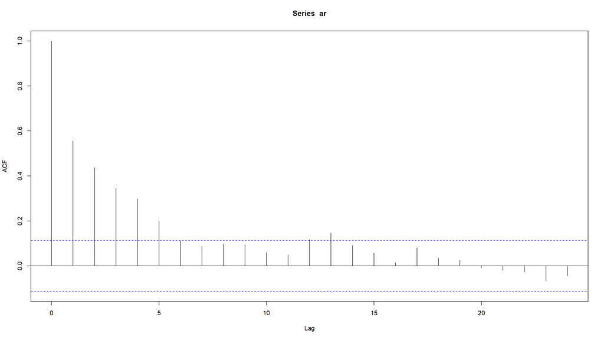

```r
acf(ar)
```

### 3.2.3 Plot PACF

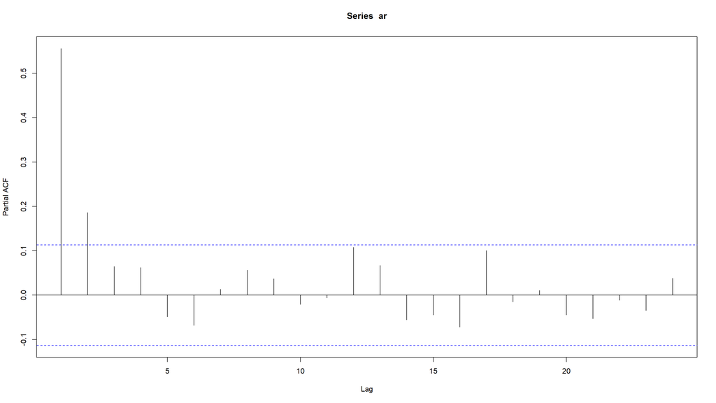

```r
pacf(ar)
```

Berdasarkan plot PACF tersebut, terlihat bahwa plot PACF *cuts off* pada lag kedua, sejalan dengan teori yang ada

### 3.2.4 Plot EACF

```r
TSA::eacf(ar)
```

```
## AR/MA
##   0 1 2 3 4 5 6 7 8 9 10 11 12 13
## 0 x x x x x o o o o o o  o  x  o
## 1 x o o o o o o o o o o  o  o  o
## 2 x o o o o o o o o o o  o  o  o
## 3 x x o o o o o o o o o  o  x  o
## 4 x x o o o o o o o o o  o  o  o
## 5 x x x o o o o o o o o  o  o  o
## 6 x x x x o o o o o o o  o  o  o
## 7 x x x x x o o o o o o  o  o  o
```

## 3.3 Scatterplot Antar Lag

### 3.3.1 Korelasi antara $Y_t$ dengan $Y_{t-1}$

```r
#Yt
yt_ar <- ar[-1]

datatable(as.matrix(yt_ar), filter = 'top',
          options = list(pageLength = 5))
```

| V1 |
| --- |
| 2 |
| 3.143481167984765 |
| 1.463997259127172 |
| 2.184457992752144 |
| 0.4886972457535475 |
| -0.03300916696612072 |
| 0.4204495464591185 |
| 0.9364777833378407 |
| -0.3781365988454542 |
| 0.9690734816285869 |

[output cut: 289 more lines]

```r
#Yt-1
yt_1_ar <- ar[-300]
datatable(as.matrix(yt_1_ar), filter = 'top',
          options = list(pageLength = 5))
```

| V1 |
| --- |
| 1 |
| 2 |
| 3.143481167984765 |
| 1.463997259127172 |
| 2.184457992752144 |
| 0.4886972457535475 |
| -0.03300916696612072 |
| 0.4204495464591185 |
| 0.9364777833378407 |
| -0.3781365988454542 |

[output cut: 289 more lines]

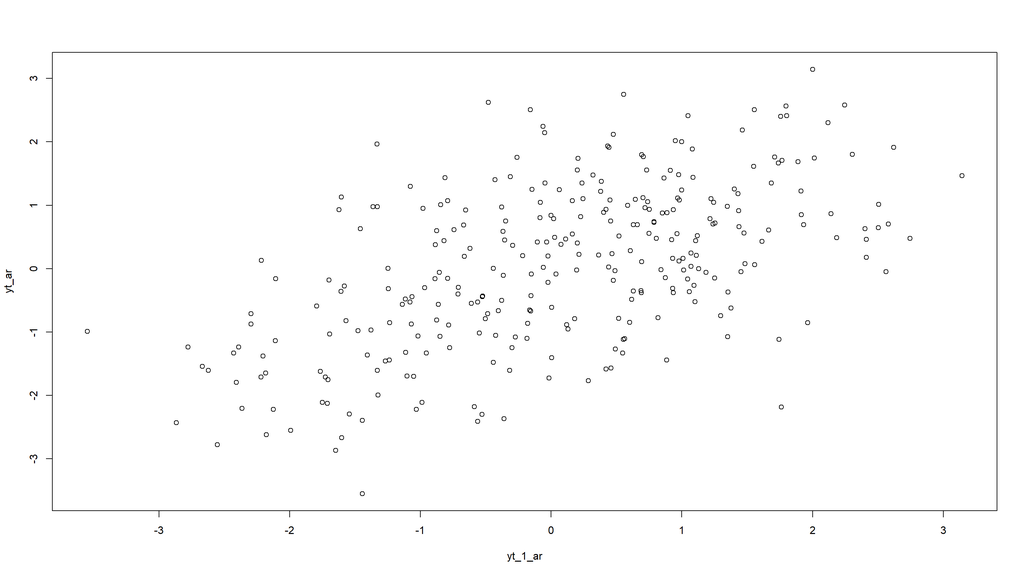

```r
plot(y=yt_ar,x=yt_1_ar)
```

Berdasarkan scatterplot tersebut, terlihat bahwa terdapat hubungan positif antara $Y_t$ dengan $Y_{t-1}$. Hal ini sesuai dengan teori yang ada

```r
cat("Nilai Korelasi : ", cor(yt_ar,yt_1_ar))
```

```
## Nilai Korelasi :  0.5571268
```

Korelasi antara $Y_t$ dengan $Y_{t-1}$ dari hasil simulasi mendekati perhitungan teoritis yaitu $\rho_1=\phi^1=0.64$

### 3.3.2 Korelasi antara $Y_t$ dengan $Y_{t-2}$

```r
#Yt
yt_ar2 <- ar[-c(1,2)]

datatable(as.matrix(yt_ar2), filter = 'top',
          options = list(pageLength = 5))
```

| V1 |
| --- |
| 3.143481167984765 |
| 1.463997259127172 |
| 2.184457992752144 |
| 0.4886972457535475 |
| -0.03300916696612072 |
| 0.4204495464591185 |
| 0.9364777833378407 |
| -0.3781365988454542 |
| 0.9690734816285869 |
| 1.11180568554818 |

[output cut: 288 more lines]

```r
#Yt-2
yt_2_ar <- ar[-c(299,300)]

datatable(as.matrix(yt_2_ar), filter = 'top',
          options = list(pageLength = 5))
```

| V1 |
| --- |
| 1 |
| 2 |
| 3.143481167984765 |
| 1.463997259127172 |
| 2.184457992752144 |
| 0.4886972457535475 |
| -0.03300916696612072 |
| 0.4204495464591185 |
| 0.9364777833378407 |
| -0.3781365988454542 |

[output cut: 288 more lines]

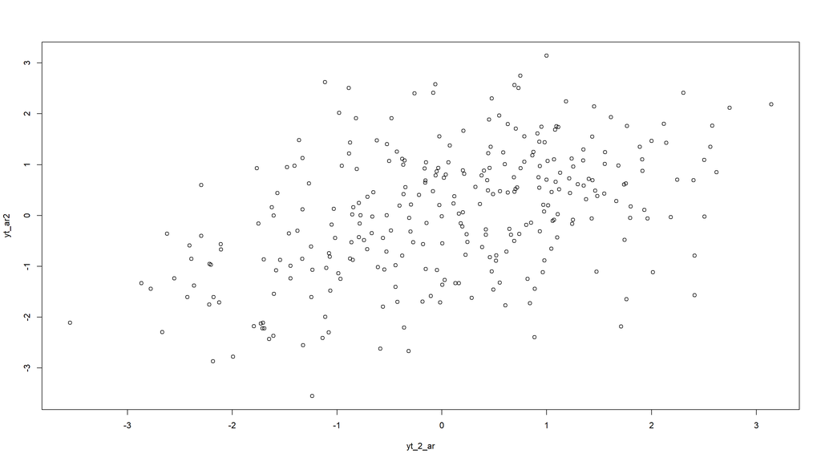

```r
plot(y=yt_ar2,x=yt_2_ar)
```

Berdasarkan scatterplot tersebut, terlihat bahwa terdapat hubungan positif antara $Y_t$ dengan $Y_{t-2}$. Hal ini sesuai dengan teori yang ada

```r
cat("Nilai Korelasi : ", cor(yt_ar2,yt_2_ar))
```

```
## Nilai Korelasi :  0.440635
```

Korelasi antara $Y_t$ dengan $Y_{t-2}$ dari hasil simulasi mendekati perhitungan teoritis yaitu $\rho_2=\phi^2=0.48$.

### 3.3.3 Korelasi antara $Y_t$ dengan $Y_{t-3}$

```r
#Yt
yt_ar3 <- ar[-c(1,2,3)]
datatable(as.matrix(yt_ar3), filter = 'top',
          options = list(pageLength = 5))
```

| V1 |
| --- |
| 1.463997259127172 |
| 2.184457992752144 |
| 0.4886972457535475 |
| -0.03300916696612072 |
| 0.4204495464591185 |
| 0.9364777833378407 |
| -0.3781365988454542 |
| 0.9690734816285869 |
| 1.11180568554818 |
| 0.2071111114831502 |

[output cut: 287 more lines]

```r
#Yt-3
yt_3_ar <- ar[-c(298,299,300)]
datatable(as.matrix(yt_3_ar), filter = 'top',
          options = list(pageLength = 5))
```

| V1 |
| --- |
| 1 |
| 2 |
| 3.143481167984765 |
| 1.463997259127172 |
| 2.184457992752144 |
| 0.4886972457535475 |
| -0.03300916696612072 |
| 0.4204495464591185 |
| 0.9364777833378407 |
| -0.3781365988454542 |

[output cut: 287 more lines]

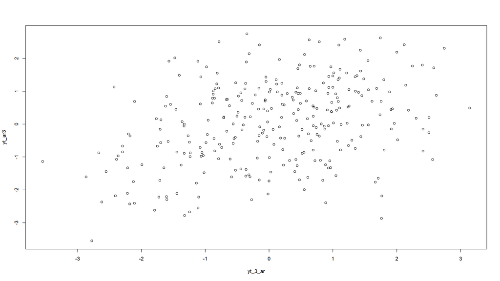

```r
plot(y=yt_ar3,x=yt_3_ar)
```

Berdasarkan scatterplot tersebut, terlihat bahwa terdapat hubungan positif antara $Y_t$ dengan $Y_{t-3}$. Hal ini sesuai dengan teori yang ada

```r
cat("Nilai Korelasi : ", cor(yt_ar3,yt_3_ar))
```

```
## Nilai Korelasi :  0.3513907
```

# 4 Fungsi pembangkitan ARMA

Setelah mengetahui cara membangkitkan data berpola AR, MA, dan ARMA sederhana, bagaimana cara melakukan pembangkitan data berpola tersebut yang lebih kompleks? Apakah dapat dibuat suatu fungsi yang fleksibel yang memungkinan pembangkitan dengan berapapun jumlah koefisien?

Pertama, lihat kembali bentuk umum data berpola ARMA.

$$y_{t} = c + \sum_{i=1}^p \phi_{i}y_{t-i} + \sum_{j=1}^q e_{t-j}+ e_{t}$$

Dari prinsip ini, dapat dibuat fungsi umum untuk membangkitkan data ARMA. Input dari fungsi adalah jumlah data yang hendak dibangkitkan, koefisien MA, dan koefisien AR.

```r
arma.sim <- function(n, macoef, arcoef){
  manum <- length(macoef)
  arnum <- length(arcoef)
  stopifnot(manum < n & arnum < n)

  wn <- rnorm(n, sd = 0.5)
  init <- max(manum, arnum)

  arma <- wn[1:init]
  for(i in {init+1}:n){
   mastart <- i - manum
   maend <- i-1
   arstart <- i - arnum
   arend <- i-1
   arma[i] <- sum(arcoef * arma[arstart:arend]) + sum(macoef * wn[mastart:maend])  + wn[i]
   }
  return(arma)
}
```

#### 4.0.0.1 **Pembangkitan Proses ARMA(2,2) manual**

```r
set.seed(006)
n = length(wn)
phi1 = 0.5
phi2 = 0.2

theta1 = 0.4
theta2 = 0.6

y.arma=c(1:n)
for (i in 5:n){y.arma[i] = phi1*y.arma[i-1] +phi2*y.arma[i-2]+ theta1*wn[i-1] + theta2*wn[i-2] +wn[i]}
datatable(as.matrix(y.arma), filter = 'top',
          options = list(pageLength = 5))
```

| V1 |
| --- |
| 1 |
| 2 |
| 3 |
| 4 |
| 4.386754500436379 |
| 2.121905304687747 |
| 1.359779560813605 |
| 0.6199870453097169 |
| 1.021940517599679 |
| 0.2011730139310686 |

[output cut: 290 more lines]

#### 4.0.0.2 **Pembangkitan Proses ARMA(2,2) manual dengan fungsi arima.sim**

Pembangkitan ARMA(p,q) juga dapat dilakukan dengan fungsi `arima.sim` sebagai berikut.

```r
arma22 <- arima.sim(list(order=c(2,0,2), ar = c(0.5,0.2), ma =c(0.4,0.6)), n=300)
datatable(as.matrix(arma22), filter = 'top',
          options = list(pageLength = 5))
```

| V1 |
| --- |
| 1.267767888053275 |
| 2.861381660908971 |
| 3.093805109622382 |
| 2.059642315534839 |
| 1.536237565727618 |
| -0.2052434784553674 |
| -1.030384751625621 |
| -0.5494597489740364 |
| -0.8211415356600246 |
| 0.7286658628648065 |

[output cut: 290 more lines]

## 4.1 **Karakteristik ARMA(2,2)**

### 4.1.1 **Plot Time Series**

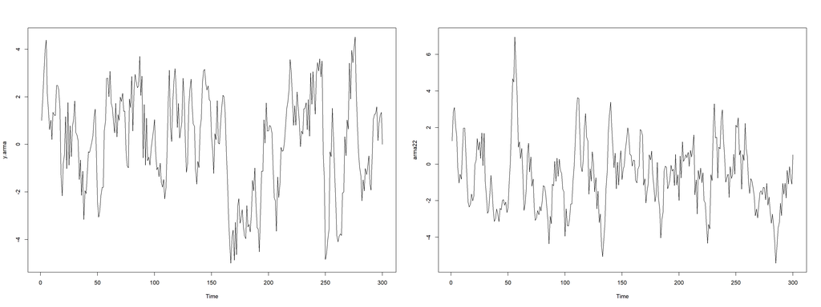

```r
par(mfrow = c(1, 2))
ts.plot(y.arma)
ts.plot(arma22)
```

```r
par(mfrow = c(1, 1))
```

Berdasarkan plot time series tersebut, terlihat bahwa model ARMA(2,2) cenderung stasioner dalam rataan

### 4.1.2 **Plot ACF**

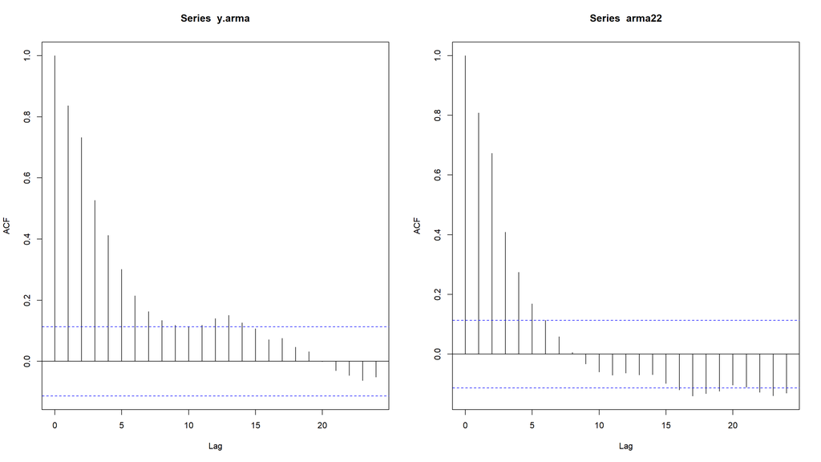

```r
par(mfrow = c(1, 2))
acf(y.arma)
acf(arma22)
```

```r
par(mfrow = c(1, 1))
```

Berdasarkan plot ACF tersebut, terlihat bahwa model ARMA(2,2) hasil simulasi memiliki plot ACF yang *tails off*, sesuai dengan teori yang ada.

### 4.1.3 **Plot PACF**

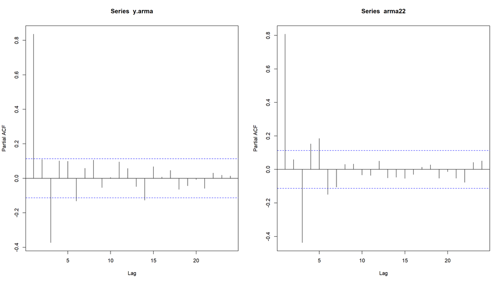

```r
par(mfrow = c(1, 2))
pacf(y.arma)
pacf(arma22)
```

```r
par(mfrow = c(1, 1))
```

Berdasarkan plot PACF tersebut, terlihat bahwa model ARMA(2,2) hasil simulasi memiliki plot PACF yang *tails off*, sesuai dengan teori.

### 4.1.4 **Plot EACF**

```r
TSA::eacf(y.arma)
```

```
## AR/MA
##   0 1 2 3 4 5 6 7 8 9 10 11 12 13
## 0 x x x x x x x x x o x  x  x  x
## 1 x x x o o o o o o o o  o  o  o
## 2 x x o x o o o o o o o  o  o  o
## 3 x x x x o o o o o o o  o  x  o
## 4 x x o x o o o o o o o  o  o  o
## 5 x x o x o o o o o o o  o  o  o
## 6 x x x x o o o o o o o  o  o  o
## 7 x x x x o o o o o o o  o  o  o
```

```r
TSA::eacf(arma22)
```

```
## AR/MA
##   0 1 2 3 4 5 6 7 8 9 10 11 12 13
## 0 x x x x x o o o o o o  o  o  o
## 1 o x x o o o o o o o o  o  o  o
## 2 x x o o o o o o o o o  o  o  o
## 3 x x o o o o x o o o o  o  o  o
## 4 x x o o o o o o o o o  o  o  o
## 5 x x x x x x o o o o o  o  o  o
## 6 x x o x o x o o o o o  o  o  o
## 7 x x x o o o x x o o o  o  o  o
```

Berdasarkan pola segitiga nol pada plot EACF, terlihat bahwa segitiga nol berada pada ordo AR(2) dan ordo MA(2).

## 4.2 **Scatterplot Antar Lag**

### 4.2.1 **Korelasi antara** $Y_t$ dengan $Y_{t-1}$

```r
#Yt
yt_arma <- arma22[-1]
datatable(as.matrix(yt_arma), filter = 'top',
          options = list(pageLength = 5))
```

| V1 |
| --- |
| 2.861381660908971 |
| 3.093805109622382 |
| 2.059642315534839 |
| 1.536237565727618 |
| -0.2052434784553674 |
| -1.030384751625621 |
| -0.5494597489740364 |
| -0.8211415356600246 |
| 0.7286658628648065 |
| 1.973102406414331 |

[output cut: 289 more lines]

```r
#Yt-1
yt_1_arma <- arma22[-300]
datatable(as.matrix(yt_1_arma), filter = 'top',
          options = list(pageLength = 5))
```

| V1 |
| --- |
| 1.267767888053275 |
| 2.861381660908971 |
| 3.093805109622382 |
| 2.059642315534839 |
| 1.536237565727618 |
| -0.2052434784553674 |
| -1.030384751625621 |
| -0.5494597489740364 |
| -0.8211415356600246 |
| 0.7286658628648065 |

[output cut: 289 more lines]

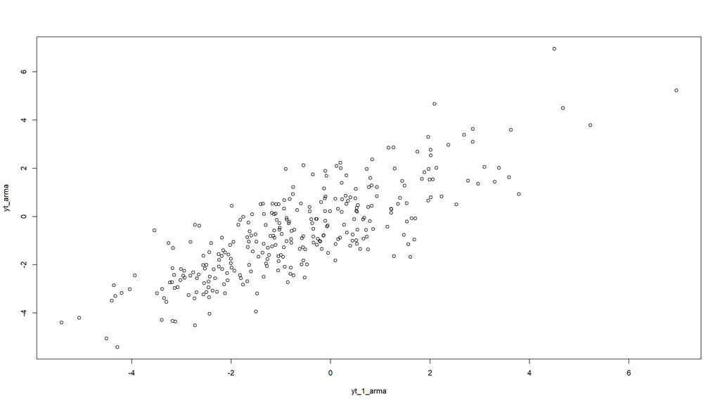

```r
plot(y=yt_arma,x=yt_1_arma)
```

Berdasarkan scatterplot tersebut, terlihat bahwa terdapat hubungan positif antara $Y_t$ dengan $Y_{t-1}$. Hal ini sesuai dengan teori yang ada.

```r
cat("Nilai Korelasi : ", cor(yt_arma,yt_1_arma))
```

```
## Nilai Korelasi :  0.8097838
```

### 4.2.2 **Korelasi antara** $Y_t$ dengan $Y_{t-2}$

```r
#Yt
yt_arma <- arma22[-c(1,2)]
datatable(as.matrix(yt_arma), filter = 'top',
          options = list(pageLength = 5))
```

| V1 |
| --- |
| 3.093805109622382 |
| 2.059642315534839 |
| 1.536237565727618 |
| -0.2052434784553674 |
| -1.030384751625621 |
| -0.5494597489740364 |
| -0.8211415356600246 |
| 0.7286658628648065 |
| 1.973102406414331 |
| 1.96386430420914 |

[output cut: 288 more lines]

```r
#Yt-1
yt_2_arma <- arma22[-c(299,300)]
datatable(as.matrix(yt_2_arma), filter = 'top',
          options = list(pageLength = 5))
```

| V1 |
| --- |
| 1.267767888053275 |
| 2.861381660908971 |
| 3.093805109622382 |
| 2.059642315534839 |
| 1.536237565727618 |
| -0.2052434784553674 |
| -1.030384751625621 |
| -0.5494597489740364 |
| -0.8211415356600246 |
| 0.7286658628648065 |

[output cut: 288 more lines]

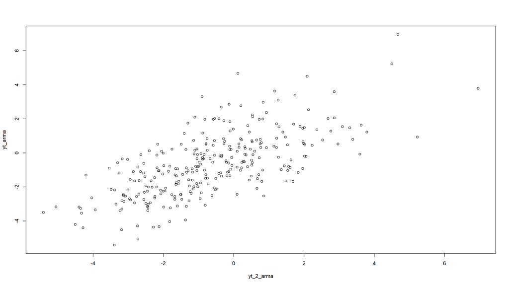

```r
plot(y=yt_arma,x=yt_2_arma)
```

Berdasarkan scatterplot tersebut, terlihat bahwa terdapat hubungan positif antara $Y_t$ dengan $Y_{t-2}$. Hal ini sesuai dengan teori yang ada.

```r
cat("Nilai Korelasi : ", cor(yt_arma,yt_2_arma))
```

```
## Nilai Korelasi :  0.678883
```

### 4.2.3 **Korelasi antara** $Y_t$ dengan $Y_{t-3}$

```r
#Yt
yt_arma <- arma22[-c(1,2,3)]
datatable(as.matrix(yt_arma), filter = 'top',
          options = list(pageLength = 5))
```

| V1 |
| --- |
| 2.059642315534839 |
| 1.536237565727618 |
| -0.2052434784553674 |
| -1.030384751625621 |
| -0.5494597489740364 |
| -0.8211415356600246 |
| 0.7286658628648065 |
| 1.973102406414331 |
| 1.96386430420914 |
| 0.6615366808759364 |

[output cut: 287 more lines]

```r
#Yt-1
yt_3_arma <- arma22[-c(298,299,300)]
datatable(as.matrix(yt_3_arma), filter = 'top',
          options = list(pageLength = 5))
```

| V1 |
| --- |
| 1.267767888053275 |
| 2.861381660908971 |
| 3.093805109622382 |
| 2.059642315534839 |
| 1.536237565727618 |
| -0.2052434784553674 |
| -1.030384751625621 |
| -0.5494597489740364 |
| -0.8211415356600246 |
| 0.7286658628648065 |

[output cut: 287 more lines]

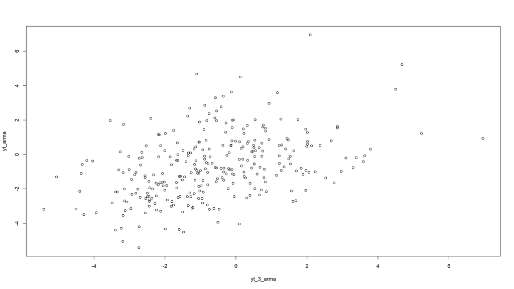

```r
plot(y=yt_arma,x=yt_3_arma)
```

Berdasarkan scatterplot tersebut, terlihat bahwa terdapat hubungan positif antara $Y_t$ dengan $Y_{t-3}$. Hal ini sesuai dengan teori yang ada.

```r
cat("Nilai Korelasi : ", cor(yt_arma,yt_3_arma))
```

```
## Nilai Korelasi :  0.4147366
```

# 5 Referensi

- Rpubs : https://rpubs.com/Prass_Code/911845
- Rmd : [Read This Nerd!](https://bookdown.org/yihui/rmarkdown-cookbook/kableextra.html)
- DT : [DT](https://rstudio.github.io/DT/)
- Theme : [Rmd Themes](https://cran.r-project.org/web/packages/rmdformats/readme/README.html)
- Hide Code : [Hide Code In RMD](https://bookdown.org/yihui/rmarkdown-cookbook/fold-show.html)
- Kable : [Kable1](https://cran.r-project.org/web/packages/kableExtra/vignettes/awesome_table_in_html.html), [Kable2](https://haozhu233.github.io/kableExtra/kableExtra_in_other_HTML_themes.html)
- Other Rmd settings : [Set1](https://stackoverflow.com/questions/23957278/how-to-add-table-of-contents-in-rmarkdown), [Set2](https://www.overleaf.com/learn/latex/Table_of_contents), [Set3](https://bookdown.org/yihui/rmarkdown/html-document.html)
- Notes : [Hanya Orang Gabut yang baca ini](https://github.com/Zen-Rofiqy/STA1381-PSD/blob/main/Proj/Curhat.txt)
- https://packer.john-coene.com/#/guide/style